# NYC Taxi

Rohan Danis-Cox

23/11/2019

## Setting Up

Before I launch into the questions I need to prepare the data a little to make sure that I have a suitable base to conduct my analysis. This is a very large data set with over 15 million observations, but it looks to be just a single month of data, from April 2013.

```r
  trip_data_raw <- read_csv("trip_data_4.csv")
  trip_fare_raw <- read_csv("trip_fare_4.csv")
  names(trip_data_raw)
  names(trip_fare_raw)
```

### Joining the data

The data comes across two spreadsheets but can be matched by joining on medallion,hack_license, vendor_id and pickup_datetime. Joining introduces a negligible increase in observations of about 1300 duplicates, mostly resulting from incorrect location data and payment types. I am expecting these to be stripped out when I clean variables next.

```r
  data <- left_join(trip_data_raw,trip_fare_raw, Joining, by = c("medallion", "hack_license", "vendor_id", "pickup_datetime"))
```

### Initial data preparation

There is a bit of fairly obvious filtering which should be done to remove observations which have:

- 0 passengers
- short trip times - say less than 30 seconds
- short trip distances - say less than 100 meters
- pickup or dropoff longitude less than -75 or greater than -73
- pickup or dropoff latitude greater than 42 or less than 40

Furthermore, I can produce a few useful features like speed and day of week. I am going to assume the trip distance variable is in miles and therefore calculate speed in miles per hour. I am also assuming that average speed should be below 70 miles per hour.

```r
  cleaning_1 <- data %>%
    filter(passenger_count != 0) %>%
    filter(trip_time_in_secs > 30) %>%
    filter(trip_distance > 0.1 ) %>%
    filter(pickup_longitude > -75 & pickup_longitude < -73) %>%
    filter(dropoff_longitude > -75 & dropoff_longitude < -73) %>%
    filter(pickup_latitude > 40 & pickup_latitude < 42) %>%
    filter(dropoff_latitude > 40 & dropoff_latitude < 42)

  cleaning_2 <- cleaning_1 %>%
    mutate(avg_speed_mh = trip_distance/trip_time_in_secs * 60 * 60) %>%
    filter(avg_speed_mh < 70)

  cleaning_3 <- cleaning_2 %>%
    mutate(pickup_hour = floor_date(pickup_datetime,"hour")) %>%
    mutate(day_of_week = wday(pickup_hour, label = TRUE))
```

This removes about 500,000 observations leaving well over 14 million.

### Splitting the data

Even though I am working from a Google Cloud Platform instance the size of the data is inhibiting my ability to move quickly. One solution to this, which will be useful down the line when modelling is to split the data into a train, validation and test set. Not only does splitting before any analysis maintain the integrity of the test set, but it also allows me to work with a smaller, more manageable dataset.

Given this, I’ve decided to go with a 50/25/25 split using sample twice to achieve the necessary splits

```r
  set.seed(11)
  index <- sample(1:nrow(cleaning_3), nrow(cleaning_3)/2)

  train <- cleaning_3[index,]
  remainder <- cleaning_3[-index,]

  set.seed(41)
  remainder_index <- sample(1:nrow(remainder), nrow(remainder)/2)
  val <- remainder[remainder_index,]
  test <- remainder[-remainder_index,]
```

There may still be a need for cleaning variables but it might be best to look at this after addressing some of the basic questions

## Basic Questions

### a. What is the distribution of number of passengers per trip?

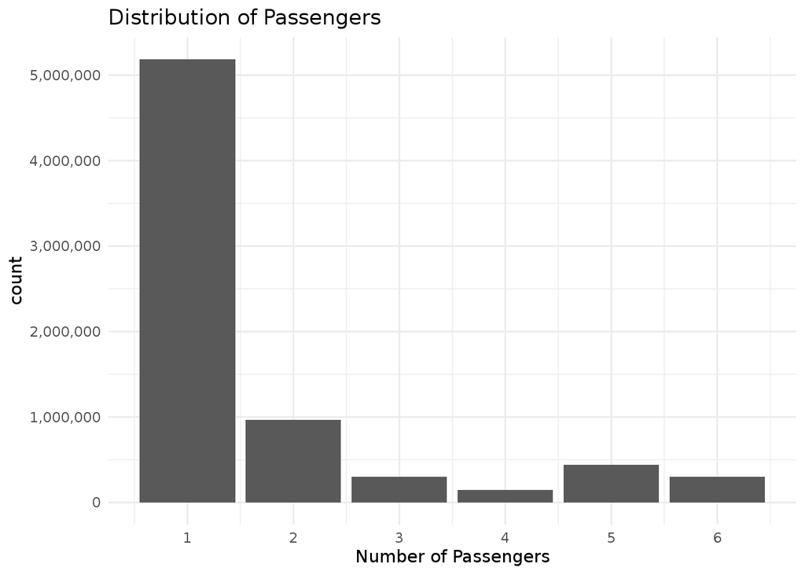

```r
  ggplot(train, aes(passenger_count)) +
    geom_bar() +
    scale_x_continuous(breaks = c(1:6)) +
    scale_y_continuous(labels = comma) +
    ggtitle("Distribution of Passengers") +
    labs(x = "Number of Passengers") +
    theme_minimal()
```

### b. What is the distribution of payment_type?

The below plot shows the frequency associated with each payment type and clearly indicates a bimodal structure within the categorical variable. Paying by cash or card represent the two options, with a variable small number of disputed, not charged or unknown payments.

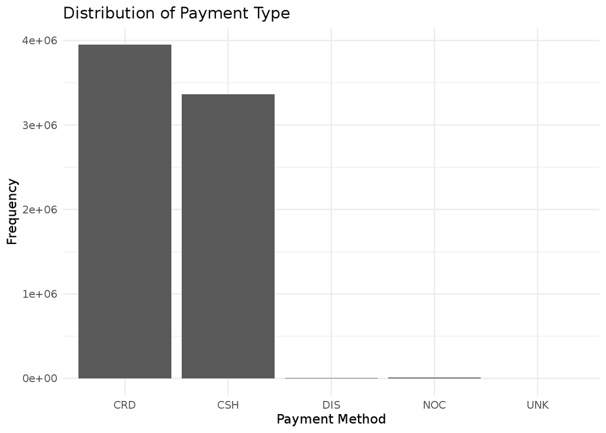

```r
  ggplot(train, aes(payment_type)) +
      geom_bar() +
      ggtitle("Distribution of Payment Type") +
      labs(x = "Payment Method", y = "Frequency") +
      theme_minimal()
```

Interestingly, I will show below that tips are only really recorded when the passenger pays with card. Cash tips are obviously just pocketed by the driver.

### c. What is the distribution of fare amount?

Fare amount is a right-skewed distribution with a median of 9.5 and a mean of 12.22. The most expensive fares are over $400 but most fares are below $50. Strangely, there is a large spike at exactly $52 which may suggest situations where the drive does not go by the meter and instead has a fixed cost for a certain route.

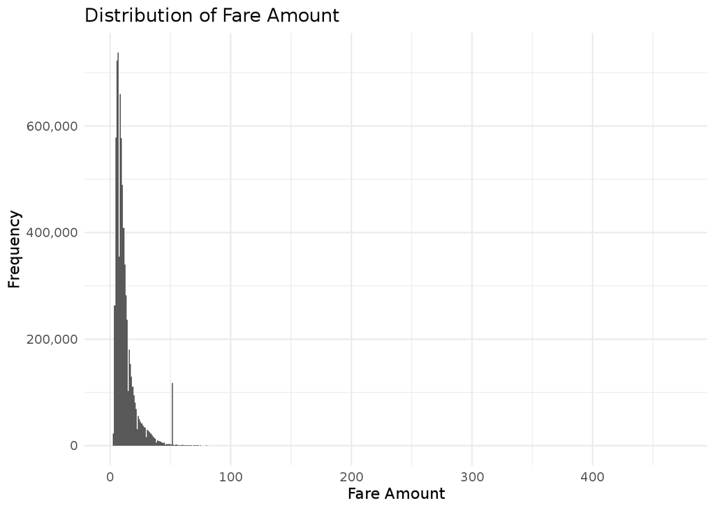

```r
  ggplot(train, aes(fare_amount)) +
      geom_histogram(bins = 500) +
      scale_y_continuous(labels = comma) +
      ggtitle("Distribution of Fare Amount") +
      labs(x = "Fare Amount", y = "Frequency") +
      theme_minimal()
```

Stealing a bit of thunder from my future investigations I am able to classify where these routes are and confirm that 65176 are picked up from JFK Airport and 44337 are being dropped off at JFK airport. As shown below, these passengers are mainly being taken to and from Manhattan.

```r
  pickup_JFK <- train_2 %>%
    select(fare_amount,pickup_zone,dropoff_borough) %>%
    filter(fare_amount == 52) %>%
    filter(pickup_zone == "JFK Airport") %>%
    count(dropoff_borough) %>%
    arrange(desc(n))

  pickup_JFK
```

```
## # A tibble: 5 x 2
##   dropoff_borough     n
##   <chr>           <int>
## 1 Manhattan       63747
## 2 Queens            808
## 3 Brooklyn          450
## 4 Bronx              87
## 5 <NA>               84
```

```r
  dropoff_JFK <- train_2 %>%
    select(fare_amount,dropoff_zone,pickup_borough) %>%
    filter(fare_amount == 52) %>%
    filter(dropoff_zone == "JFK Airport") %>%
    count(pickup_borough) %>%
    arrange(desc(n))

  dropoff_JFK
```

```
## # A tibble: 6 x 2
##   pickup_borough     n
##   <chr>          <int>
## 1 Manhattan      43209
## 2 Queens           891
## 3 Brooklyn         167
## 4 <NA>              55
## 5 Bronx             14
## 6 Staten Island      1
```

### d. What is the distribution of tip amount?

The below plot shows the distribution of tip amount as predominatly 0 and then tailing off despite some large outlier tip values.

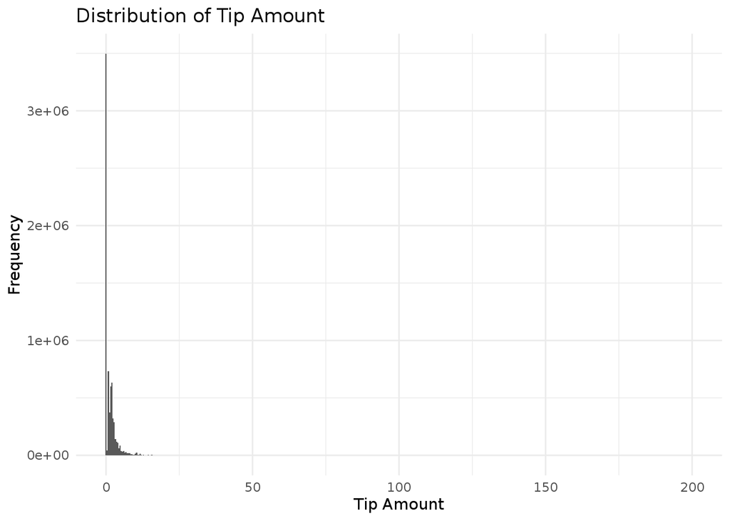

```r
  ggplot(train,aes(tip_amount)) +
      geom_histogram(bins = 500) +
      ggtitle("Distribution of Tip Amount") +
      labs(x = "Tip Amount", y = "Frequency") +
      theme_minimal()
```

This plot isn’t very clear so I have zoomed in on the data to show tips up to $20 and colour coded this based on the payment method. It is clear from this plot that drivers are more than likely receiving tips but just not recording them when the payment is with cash.

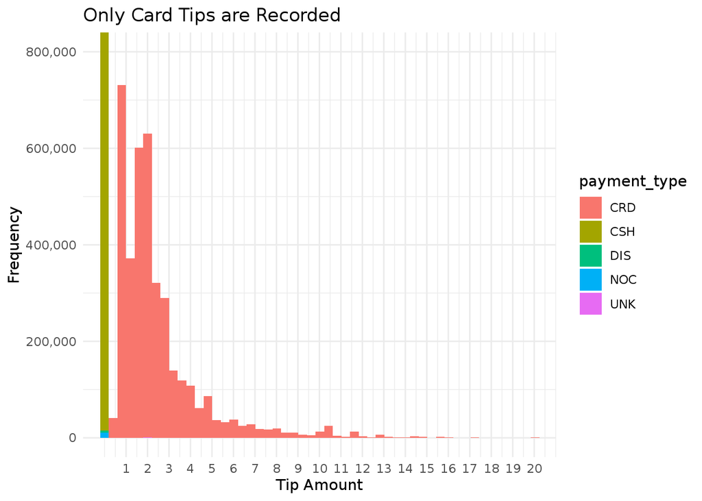

The distribution of only card payments, where we can more reliably consider the tip amount resembles a poisson distribution around a mean of 2.48.

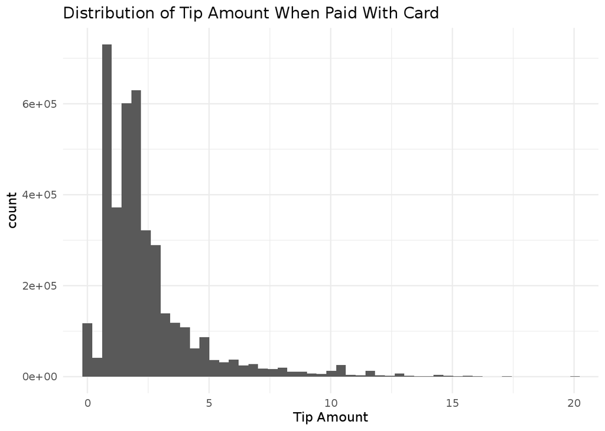

### e. What is the distribution of total amount?

The distribution of total amount looks much like that of fare amount, that is a heavily right-skewed distributon, although the spike at $52 has been washed out somewhat by tips and taxes.

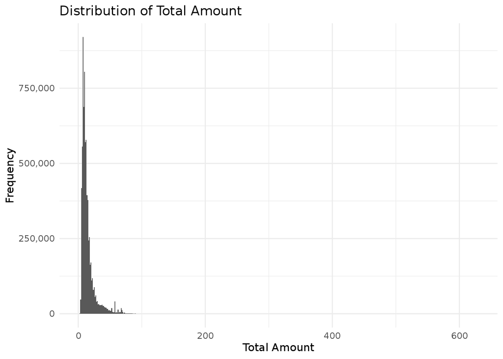

### f. What are top 5 busiest hours of the day?

As one might expect, the busiest hours for taxis are in the evening, where between 6-11pm where there is a noticeable platform compared with the rest of the day.

```r
  busy_hours <- train %>%
    group_by(pickup_hour) %>%
    summarise(count= n()) %>%
    mutate(rank = rank(desc(count))) %>%
    mutate(top_5 = case_when(rank <= 5 ~ "Yes",
                             TRUE ~ "No"))
```

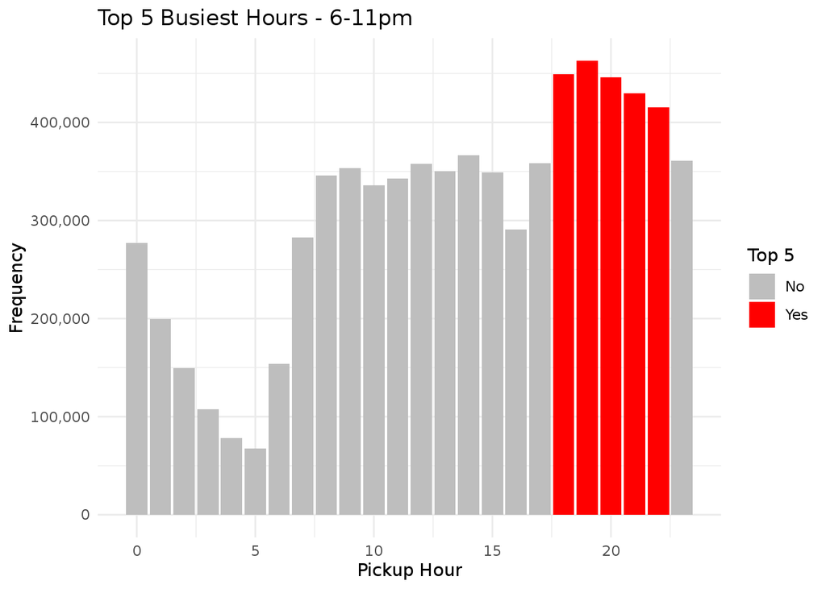

It would be interesting to see how working in the period of time performs as one might expect it the market to be saturated with relatively short low yield trips as people travel to meet engagements.

### g. What are the top 10 busiest locations of the city?

As touched on earlier, with this question in mind I sourced some additional spatial data to help make sense of the location coordinates provided in the data set. The below plot shows why I feel this was necessary, as each coordinate was relatively distinct and so made it very challenging to group the data.

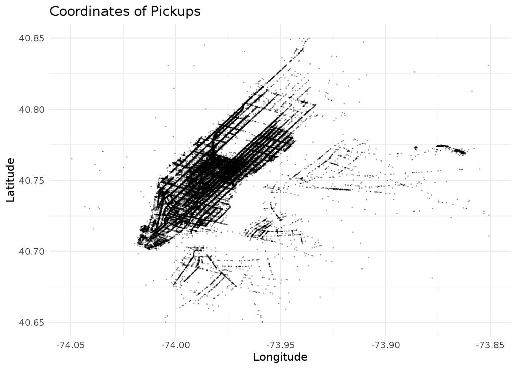

I could have rounded the coordinates to generate a grid system, and this is what I would have attempted if I wasn’t able to locate a shapefile which served a similar purpose but provided more meaning to the data.

Fortunately I found a great shapefile of taxi zones at the [Taxi and Limousine commision site](https://www1.nyc.gov/site/tlc/about/tlc-trip-record-data.page) and I was able to join the data based on the simple features themselves - see investigations file for how this was done.

```r
  busy_pickup_locations <- train_2 %>%
    group_by(pickup_zone) %>%
    summarise(pickup= n())

  busy_dropoff_locations <- train_2 %>%
    group_by(dropoff_zone) %>%
    summarise(dropoff= n())

  taxi_zones_to_borough <- taxi_zone_busy %>%
    select(zone,borough) %>%
    st_drop_geometry()

  busy_overall <- busy_pickup_locations %>%
    left_join(busy_dropoff_locations, by = c("pickup_zone" = "dropoff_zone")) %>%
    mutate(overall = pickup + dropoff) %>%
    left_join(taxi_zones_to_borough, by = c("pickup_zone" = "zone")) %>%
    select(zone = pickup_zone, borough, overall) %>%
    mutate(rank = rank(desc(overall))) %>%
    mutate(top_10 = case_when(rank <= 10 ~ "Yes",
                             TRUE ~ "No"))

  busy_overall %>% filter(top_10 == "Yes") %>% arrange (desc(overall)) %>% select(zone, borough,trips = overall)
```

```
## # A tibble: 10 x 3
##    zone                         borough    trips
##    <chr>                        <chr>      <int>
##  1 Midtown Center               Manhattan 560457
##  2 Upper East Side South        Manhattan 530373
##  3 Upper East Side North        Manhattan 507909
##  4 Murray Hill                  Manhattan 494400
##  5 Midtown East                 Manhattan 487248
##  6 Times Sq/Theatre District    Manhattan 481249
##  7 Union Sq                     Manhattan 474616
##  8 East Village                 Manhattan 432718
##  9 Clinton East                 Manhattan 420493
## 10 Penn Station/Madison Sq West Manhattan 405917
```

The above table shows that the busiest locations, as measured by taxi zones of pickups and dropoffs are all in Manhattan.

Visualising the data on a map clearly shows Manhattan’s prominence but also indicates a large number of trips to the airports at La Guardia and JFK.

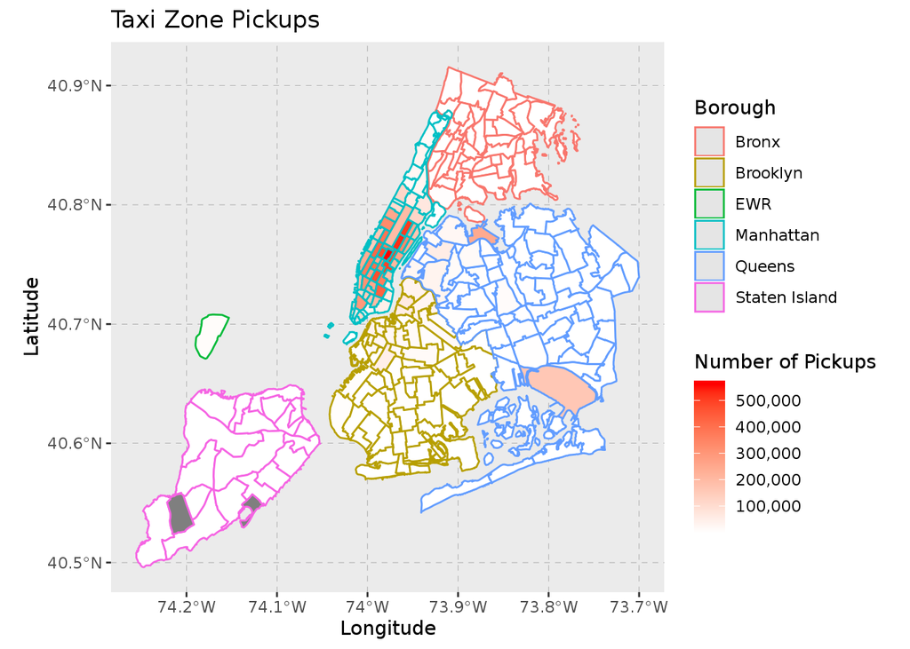

```r
  ggplot(taxi_zone_busy) +
    geom_sf(mapping = aes(fill = overall, colour = borough)) +
    scale_fill_gradient(low = "white", high = "red", label = comma) +
    ggtitle("Taxi Zone Pickups") +
    labs(x = "Longitude", y = "Latitude", fill = "Number of Pickups", colour = "Borough") +
    theme(panel.grid.major = element_line(color = gray(0.5), linetype = "dashed", size = 0.1))
```

### h. Which trip has the highest standard deviation of travel time?

Originally I wanted to classify this using a trip consisting of a zones and hours. The reason I wanted to do this is that travel time could be expected to vary greatly based on traffic (which was probably the actual intent of the question). But when I did this JFK to JFK showed up pretty unanimously at all hours. This is probably fair since a some trips would have been a few hundred meters down the road and surely others would have been half-way across the city and back to retrieve important items.

```r
  high_sd_time <- train_2 %>%
    group_by(pickup_zone,dropoff_zone) %>%
    summarise(st_dev_time = sd(trip_time_in_secs),
              average_distance = mean(trip_distance),
              n = n()) %>%
    filter(!is.na(pickup_zone)) %>%
    filter(!is.na(dropoff_zone)) %>%
    filter(n > 20) %>%
    arrange(desc(st_dev_time)) %>%
    ungroup() %>%
    head(10)

  high_sd_time
```

```
## # A tibble: 10 x 5
##    pickup_zone            dropoff_zone        st_dev_time average_distance     n
##    <chr>                  <chr>                     <dbl>            <dbl> <int>
##  1 Maspeth                JFK Airport               1944.            13.6     23
##  2 South Jamaica          Midtown South             1756.            12.0     21
##  3 JFK Airport            JFK Airport               1468.             4.98  2051
##  4 Flushing Meadows-Coro… Times Sq/Theatre D…       1468.            10.5     38
##  5 Garment District       Flushing                  1242.            11.1     23
##  6 Flushing Meadows-Coro… JFK Airport               1217.            10.7     47
##  7 LaGuardia Airport      Brighton Beach            1214.            21.3     38
##  8 Penn Station/Madison … South Ozone Park          1175.            15.2     33
##  9 JFK Airport            West Chelsea/Hudso…       1168.            17.1    544
## 10 JFK Airport            Newark Airport            1167.            31.6     70
```

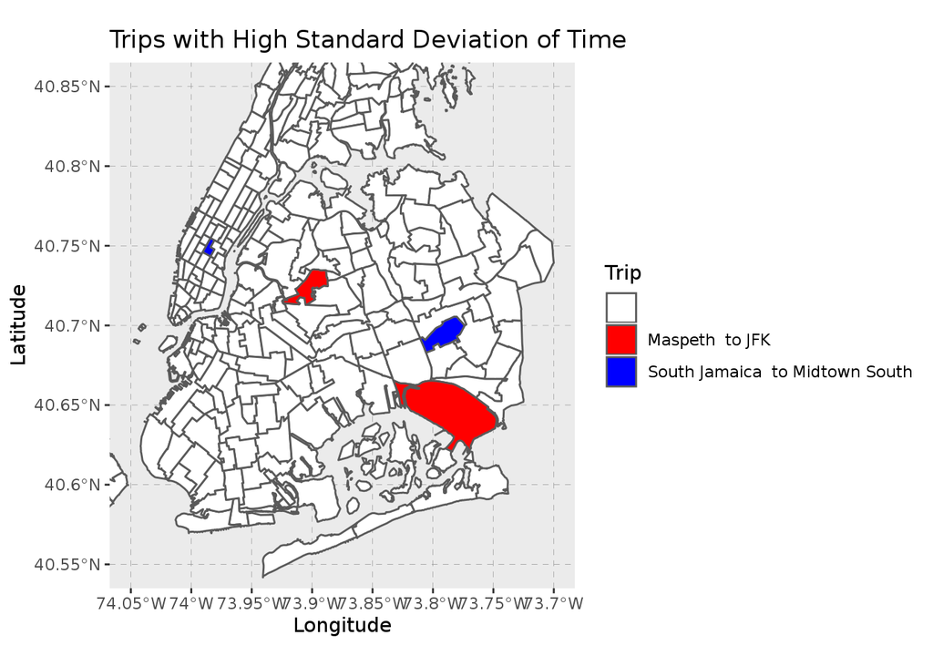

### i. Which trip has most consistent fares?

Again, this makes sense as they are predominatenly stort trips, mostly below 2 miles.

```r
  low_sd_fare <- train_2 %>%
    group_by(pickup_zone,dropoff_zone) %>%
    summarise(st_dev_fare = sd(total_amount),
              average_distance = mean(trip_distance),
              n = n()) %>%
    filter(!is.na(pickup_zone)) %>%
    filter(!is.na(dropoff_zone)) %>%
    filter(n > 20) %>%
    arrange(st_dev_fare) %>%
    ungroup() %>%
    head(10)

  high_sd_time
```

[output not shown]

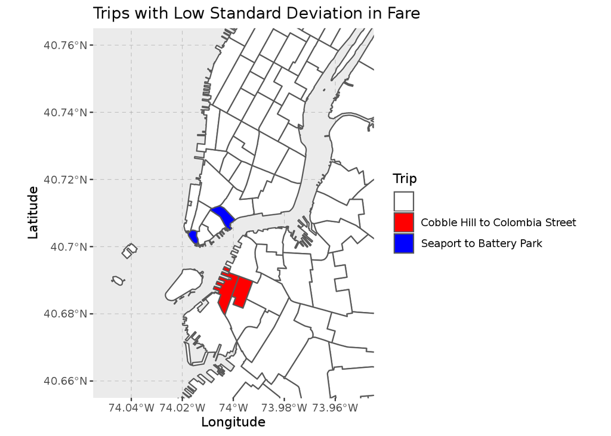

## Open Questions

### a. In what trips can you confidently use respective means as measures of central tendency to estimate fare, time taken, etc.

Mean can be used as a measure of central tendancy when the data is symetrical, i.e. not exihibiting signs of skewness. As established above, fare is heavily right-skewed when viewing the data as a whole, but when looking at particular trips it could be expected that you would see distributions which are more normally distributed.

We can look at parametric statistical tests to understand how a sample distribution compares to a normal distribution, with one example being the Shapiro-Wilk’s test. A statisitc close to 1 suggests normal distribution but it is best to view the histogram or qplot to confirm.

Just a quick aside, when applying the Shapiro-Wilk test in R the sample size is limited to between 3 and 5000. This is primarily because the null hypothesis is that the distibution is normal (which is odd for an hypothesis test as usually it would be the other way around) and very small samples tend to confirm the null while very large sample sizes tend to reject the null.

Let’s take a look at the fare over trips:

```
## # A tibble: 10 x 4
##    trip                                  statistic p.value method
##    <chr>                                     <dbl>   <dbl> <chr>
##  1 Midtown North to Seaport                  0.990  0.0895 Shapiro-Wilk normali…
##  2 JFK Airport to Queens Village             0.995  0.613  Shapiro-Wilk normali…
##  3 Central Park to Lower East Side           0.993  0.354  Shapiro-Wilk normali…
##  4 World Trade Center to Gramercy            0.992  0.0275 Shapiro-Wilk normali…
##  5 Central Park to Stuy Town/Peter Coop…     0.992  0.603  Shapiro-Wilk normali…
##  6 Central Park to Two Bridges/Seward P…     0.994  0.952  Shapiro-Wilk normali…
##  7 Times Sq/Theatre District to East El…     0.990  0.236  Shapiro-Wilk normali…
##  8 Central Park to Washington Heights N…     0.993  0.685  Shapiro-Wilk normali…
##  9 SoHo to Stuyvesant Heights                0.991  0.775  Shapiro-Wilk normali…
## 10 Astoria to Flushing                       0.991  0.956  Shapiro-Wilk normali…
```

The above table shows the top 10 trips based on the Shapiro-Wilk test. Examining one of these examples, we would expect to see data which is normally distributed.

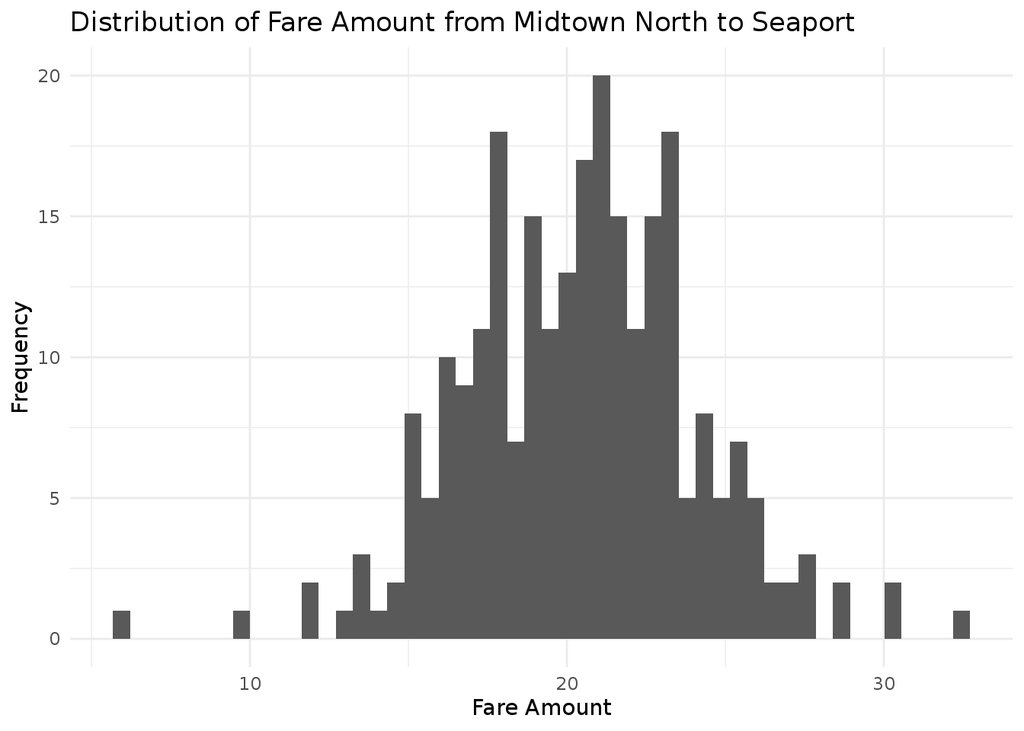

```r
  shap_fare_2 <- shap_fare %>%
    filter(!str_detect(trip,"JFK")) %>%
    top_n(-10,statistic)

  shap_fare_2
```

```
## # A tibble: 10 x 4
##    trip                                   statistic  p.value method
##    <chr>                                      <dbl>    <dbl> <chr>
##  1 Brooklyn Heights to Cobble Hill            0.213 8.47e-32 Shapiro-Wilk norma…
##  2 Midtown East to UN/Turtle Bay South        0.117 2.15e-87 Shapiro-Wilk norma…
##  3 Long Island City/Queens Plaza to Old …     0.102 1.57e-32 Shapiro-Wilk norma…
##  4 Baisley Park to Times Sq/Theatre Dist…     0.121 1.30e-19 Shapiro-Wilk norma…
##  5 East Harlem South to Manhattanville        0.198 2.32e-30 Shapiro-Wilk norma…
##  6 South Williamsburg to Williamsburg (S…     0.163 1.27e-19 Shapiro-Wilk norma…
##  7 Baisley Park to Midtown North              0.137 1.21e-14 Shapiro-Wilk norma…
##  8 Baisley Park to Murray Hill                0.129 2.44e-15 Shapiro-Wilk norma…
##  9 Baisley Park to Midtown East               0.113 6.16e-17 Shapiro-Wilk norma…
## 10 Springfield Gardens South to Times Sq…     0.167 1.42e-13 Shapiro-Wilk norma…
```

On the other hand, this table shows some low scoring trips (I’ve excluded trips involving JFK as the already established $52 fares create some very strange distributions), and we would expect to see data that is not normally distributed. These would be cases where you would probably not want to use the mean as a central measure of tendancy. Such at the below, where the mean value would be raised away from the mode and median by a few significant outliers.

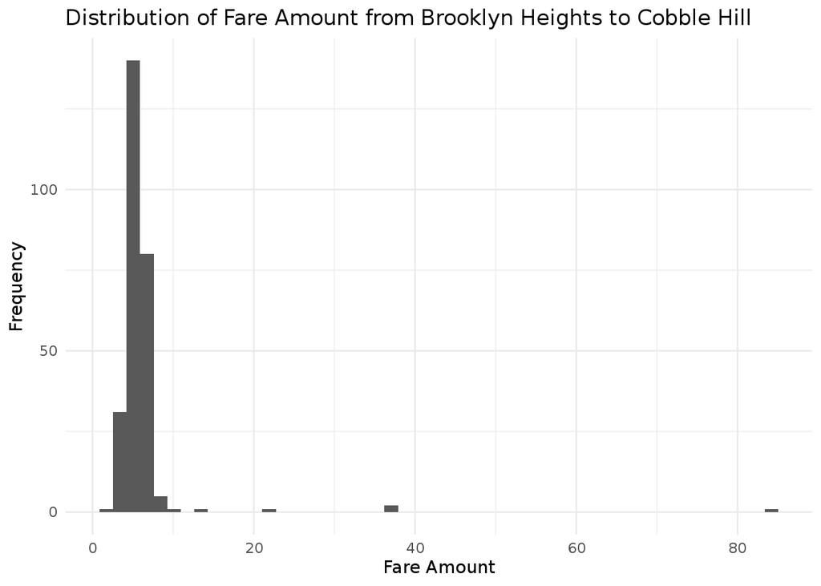

The same can be done for trip time:

```
## # A tibble: 10 x 4
##    trip                               statistic    p.value method
##    <chr>                                  <dbl>      <dbl> <chr>
##  1 Financial District North to Centr…     0.992    2.40e-1 Shapiro-Wilk normali…
##  2 Bloomingdale to Union Sq               0.996    9.07e-1 Shapiro-Wilk normali…
##  3 Upper East Side South to SoHo          0.991    1.32e-7 Shapiro-Wilk normali…
##  4 Upper East Side North to SoHo          0.991    7.06e-4 Shapiro-Wilk normali…
##  5 Lincoln Square East to Little Ita…     0.992    1.12e-4 Shapiro-Wilk normali…
##  6 Bloomingdale to Greenwich Village…     0.992    8.69e-1 Shapiro-Wilk normali…
##  7 Upper West Side South to Little I…     0.993    5.03e-2 Shapiro-Wilk normali…
##  8 Bloomingdale to Murray Hill            0.992    3.37e-1 Shapiro-Wilk normali…
##  9 Manhattanville to Lincoln Square …     0.993    9.54e-1 Shapiro-Wilk normali…
## 10 Murray Hill to Bedford                 0.992    4.14e-1 Shapiro-Wilk normali…
```

And we would expect a similar result:

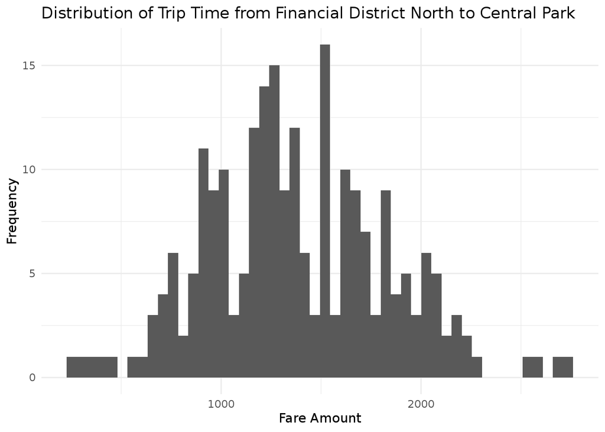

### b. Can we build a model to predict fare and tip amount given pick up and drop off coordinates, time of day and day of week?

Thinking logically, we should be able to predict fares with reasonable accuracy. My belief for this stems from the prescibed nature of fares where we could expect variables like distance travelled, length of trip, number of passengers, time of day, tolls etc to be taken into account in determining a fare. Whether we can accurately predict the fare from only location, time of day and DAY of week is less clear (I am assuming the question meant to say day of week as this would seem to me to make more sense).

In terms of tip amount, we have already established that the data only captures tip amounts when they are paid by card. Even if I were to isolate for this, I wouldn’t expect a model to be very effective in estimating tip amounts as it depends on many more human variables which are very challenging to measure. How generous is the passenger? How friendly was the driver? How urgent was the trip? All variables that are going to be very challenging to measure.

Below I have demonstrated how a random forest using only 5,000 observations from the training set can do an okay job at predicting fare amount. To aid the algorithm I have simplified time of day into 5 periods.

```
## # A tibble: 6 x 8
##   pickup_longitude pickup_latitude dropoff_longitu… dropoff_latitude day_of_week
##              <dbl>           <dbl>            <dbl>            <dbl> <fct>
## 1            -74.0            40.8            -73.9             40.8 Mon
## 2            -74.0            40.7            -74.0             40.8 Mon
## 3            -74.0            40.8            -74.0             40.8 Sat
## 4            -74.0            40.7            -74.0             40.7 Wed
## 5            -74.0            40.8            -74.0             40.8 Sun
## 6            -74.0            40.8            -74.0             40.7 Mon
## # … with 3 more variables: pickup_time <fct>, fare_amount <dbl>, pred <dbl>
```

```
## # A tibble: 1 x 1
##    rmse
##   <dbl>
## 1  4.14
```

This model achieves an root mean squared error (RMSE) of 4.1429636. This suggests that on average the predicted values are about 4.14 dollars away from the actual value of fare amount. The below plot of actual vs predicted values shows that this model performs relatively well.

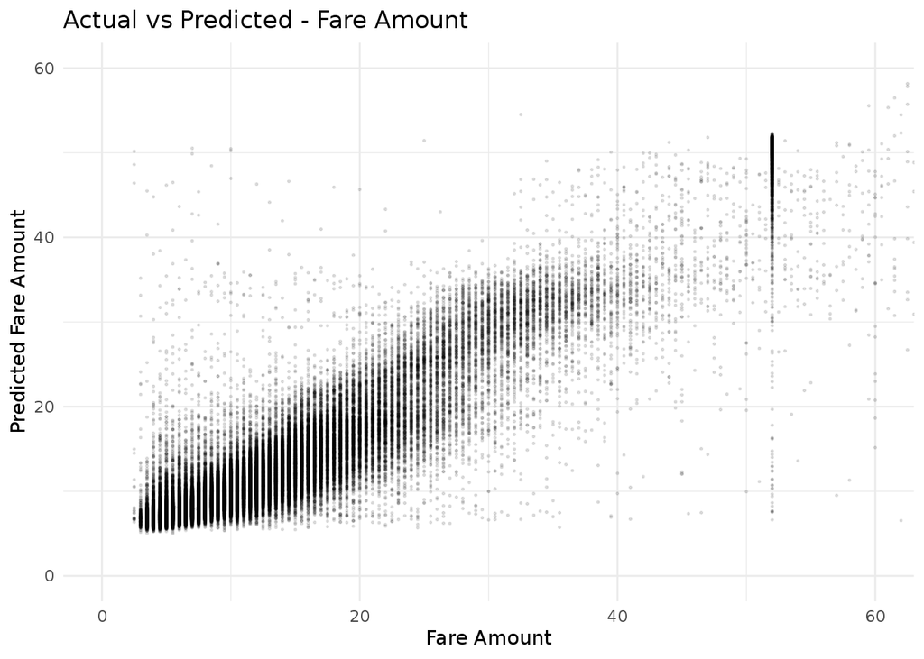

Taking aim at tip amount the below model shows that RMSE alone may not tell the whole story.

This model achieves an RMSE of 1.8154988. This suggests that on average the predicted values are about 1.82 dollars away from the actual value of tip amount. However, the below plot of actual vs predicted values shows that the model tends to underestimate tip amount. I’d suspect that this was on account of the 0 values coming from cash transactions.

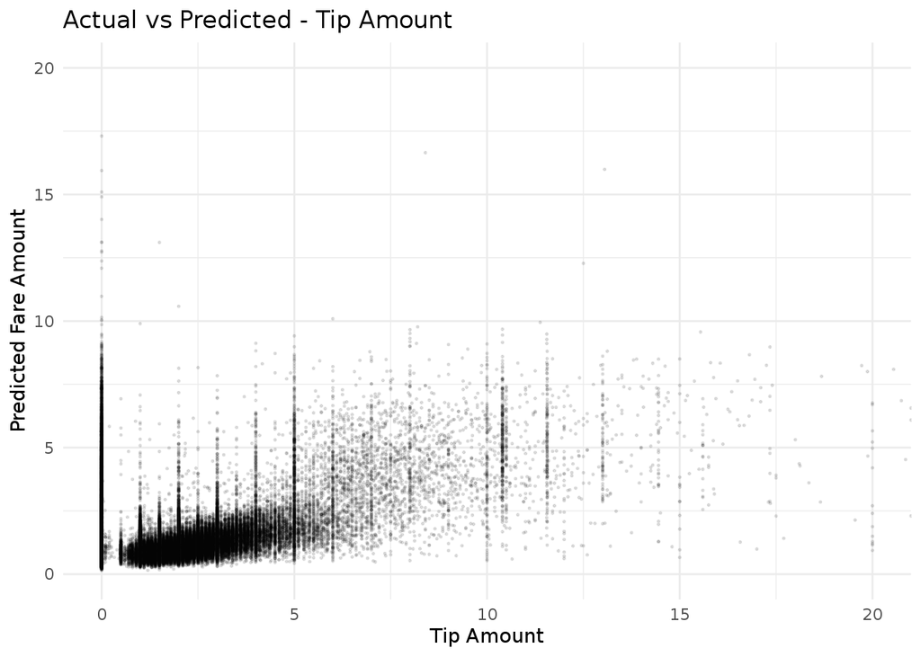

### c. If you were a taxi owner, how would you maximize your earnings in a day?

### d. If you were a taxi owner, how would you minimize your work time while retaining the average wages earned by a typical taxi in the dataset?

### e. If you run a taxi company with 10 taxis, how would you maximize your earnings?